# Presidential Elections: 1.6

Sono Shah

2017-08-17

# Plan for the rest of the class

- 2 more lab assignments
- Final Paper Prompt will be given at the end of Thursday’s Class Due 9/2 before 9PM.

# Lab Assignments

- Lab I & II will be divided into 3 parts **each** for = 6 grades for first 2 labs
- Lab III & IV will be planned for Tuesday and Thursday next week, divded into 2 parts each = 4 grades for last two labs
- Lab II and Lab IV will have a late penalty if not turned in on time.

# Presidential Campaigns

- Chapter 9: Presidential Campaigns

# Goals of Presidential Campaigns

- Win your party nomination
- Win enough states in the general election to get at least 270 votes
- goals can create conflict

# Incompatible

- nomination = winning a plurality of partisans
- partisans tend to more ideological than the average voter
- gives candidates incentive to move away from the political center

# Incompatibility

- appealing to a more centrist general election voters can alienate hard-core partisans who play a major role in primaries and caucuses

# Winning the nomination

- Primaries & Caucuses
- These elections determine who the state party will send to represent the state at the national party nominating convention (representatives called delegates)

# Caucuses

- registered partisans attend meetings at election precinct locations and vote to elect delegates to the county or state party conventions

# Primaries

- Closed: only registered Democrats can vote in the Democratic primary and only registered Republicans can vote in the Republican primary
- Open: voters can choose the primary in which they will vote, regardless of their party, but they may only vote in one party’s primary
- Semi-closed: both unaffiliated and those registered as members of a party can vote in that party’s primary

# Awarding Delegates

- most states award delegates proportionally
- i.e. A candidate wins with 40% of the primary vote= they get 40% of the delegates

# Super Delegates

- Democratic Nomination process
- AKA *at-large* delegates, not pledged to any candidate
- officeholders or occupy certain positions within the party

# 2016 Democratic Primary

# 2016 Republican Primary

[video not shown]

# Nomination strategy

- States jockey for position to hold the earliest primary
- Gives them greater influence on the nomination process

# Running mate

- helps you compensate for shortcomings of presidential candidate
- helps you carry state or region
- helps you carry political or demographic group
- heal intra-party wounds
- helps reinforce image of the candidate

# Electoral College Strategy

- Campaigns look at how competitive each state is,
- How critical is it to get to 270,
- The cost of campaigning there relative to other states

# Electoral College Strategy

1. California 55 (55)
2. Texas 38 (93)
3. New York 29 (122) 4.Florida 29 (151)
4. Pennsylvania 20 (171)
5. Illinois 20 (191)
6. Ohio 18 (209)
7. Michigan 16 (225)
8. Georgia 16 (241)
9. North Carolina 15 (256)
10. New Jersey 14 (270)

# Electoral College Strategy

- Winning the minimum amount of votes in each of the 11 states means that a candidate could win the Presidency with just **27%** of the population vote.[^1](http://www.npr.org/2016/11/02/500112248/how-to-win-the-presidency-with-27-percent-of-the-popular-vote)

# Political & Economic Realities

- incumbency
- war
- the economy

# Incumbency Advantage!

- experience
- office of the presidency + name recognition
- easier road to the party nomination (typically)

# Incumbency Disadvantages!

- Historically wars have more often had a negative impact on the incumbent president’s reelection bid
- The candidate of the incumbent party and esp. the incumbent president is **much more** likely to win if the economy is growing strongly.

# Economy

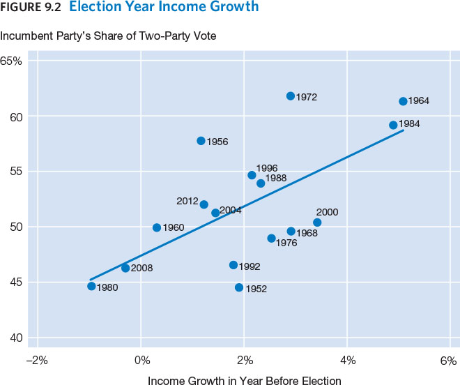

[^1]: NPR↩